# Tarea 3: Análisis Espacial y Temporal de la Precipitación en la Cuenca del Río Liberia

PF-0953 Programación en R (2026-II)

Autor/a

Dennier Chávez Garro

Fecha de publicación

16 de noviembre de 2026

**Mostrar el código**

```r
# Ecosistema tidyverse y manejo de datos
library(tidyverse)
library(readr)
library(dplyr)
library(scales)
library(lubridate)

# Visualización interactiva y tablas
library(plotly)
library(DT)

# Análisis geoespacial y cartografía
library(sf)
library(leaflet)
library(ggspatial)

# Tipografías y presentación
library(showtext)
```

# 1 Introducción

La ciudad de Liberia, en la provincia de Guanacaste, ubicada en la región Pacífico Norte de Costa Rica, presenta un alta varibilidad climática que la hace particularmente vulnerable a fenómenos meteorológicos extremos. Durante la época lluviosa, la influencia de ondas tropicales, sistemas de baja presión y huracanes genera precipitaciones de alta intensidad que frecuentemente superan la capacidad de infiltración del suelo y el caudal máximo de diseño de las infraestructuras de drenaje existentes. Esta situación provoca desbordamientos en los cauces, generando inundaciones que afectan severamente a las comunidades locales, la infraestructura civil y las actividades agrícolas.

Adicional a los efectos sobre el territorio provocados por las lluvias, se encuentra la falta de planificación urbana, que contribuye a la construcción de nuevos asentamientos, incluyendo complejos residenciales de alto costo en zonas limítrofes con ríos.

En este contexto, el presente análisis se centra en la evaluación de los datos de precipitación obtenidos del conjunto de datos del *Climate Hazards Group InfraRed Precipitation with Station data* (CHIRPS), que combina información de sensores satelitales y, de estaciones meteorológicas para proporcionar estimaciones de la precipitación diaria. El objetivo es identificar patrones de precipitación, evaluar la variabilidad temporal y espacial, y generar visualizaciones que faciliten la comprensión de los riesgos asociados a eventos extremos de lluvia en Liberia.

Como una variable adicional, se utilizan los datos de temperatura para elaborar un escenario de las condiciones climáticas. Estos registros se obtuvieron del sensor satelital *ERA5-Land Daily Aggregated* (ECMWF).

Los registros, para el período enero 2026 a setiembre 2026, se incluyeron en un archivo .csv. En la Tabla 1.1 se muestran los valores diarios, para un punto en la cuenca del río Liberia.

**Mostrar el código**

```r
# Lectura única del dataset puntual de la Tarea 2
url_t2 <- "https://raw.githubusercontent.com/dennierchavez/tarea_2/refs/heads/main/CHIRPS.csv"
precipitacion_t2 <- read_csv(url_t2, show_col_types = FALSE) |>
  mutate(
    date = as.Date(date),
    precipitation = coalesce(as.numeric(precipitation), 0)
  )

# Renderizado de la tabla con DT
precipitacion_t2 |>
  mutate(
    across(any_of(c("lon", "lat")), ~ round(.x, 5)),
    across(where(is.numeric) & !any_of(c("lon", "lat")), ~ round(.x, 2))
  ) |>
  rename(any_of(c(
    "ID"                 = "id",
    "Longitud"           = "lon",
    "Latitud"            = "lat",
    "Fecha"              = "date",
    "Precipitación (mm)" = "precipitation",
    "Temp. Media (°C)"   = "tmean",
    "Temp. Mínima (°C)"  = "tmin",
    "Temp. Máxima (°C)"  = "tmax"
  ))) |>
  datatable(
    rownames = FALSE,
    options = list(
      pageLength = 10,
      autoWidth = TRUE,
      language = list(
        search = "Buscar:",
        lengthMenu = "Mostrar _MENU_ registros",
        info = "Mostrando _START_ a _END_ de _TOTAL_ registros",
        paginate = list(previous = "Anterior", `next` = "Siguiente")
      )
    )
  )
```

Tabla 1.1: Registro diario de precipitación y temperatura en Liberia (Enero–Septiembre 2026)

| Fecha | Precipitación (mm) | Temp. Máxima (°C) | Temp. Media (°C) | Temp. Mínima (°C) |
| --- | --- | --- | --- | --- |
| 2026-01-01 | 0 | 29.78 | 26.05 | 23.52 |
| 2026-01-02 | 0 | 29.45 | 25.26 | 22.14 |
| 2026-01-03 | 0 | 31.62 | 26.24 | 22.35 |
| 2026-01-04 | 0 | 32.18 | 26.53 | 20.94 |
| 2026-01-05 | 0 | 30.07 | 26.49 | 23.37 |
| 2026-01-06 | 0 | 31.32 | 26.43 | 22.9 |
| 2026-01-07 | 0 | 30.92 | 26.24 | 22.35 |
| 2026-01-08 | 0 | 32.21 | 26.64 | 22.84 |
| 2026-01-09 | 0 | 31.61 | 27.04 | 23.68 |
| 2026-01-10 | 0 | 31.65 | 26.86 | 23.27 |

[output cut: 263 more lines]

En este documento se presentan los resultados del análisis de precipitación, incluyendo la visualización de la precipitación diaria, la temperatura media diaria y la curva masa de precipitación acumulada. Se pretende dar respuesta a tres interrogantes:

1. ¿Cuál es la distribución temporal de la precipitación diaria en Liberia durante el periodo de enero a septiembre de 2026?
2. ¿Cómo se comporta la temperatura media diaria en el mismo periodo y qué relación tiene con la precipitación?
3. ¿Cual es el comportamiento de la precipitación acumulada a lo largo del tiempo y cómo se puede representar mediante una curva masa interactiva?

Con respecto al componente espacial, y dado que se cuenta con una base de datos que relaciona precipitación en series de tiempo para 100 puntos de muestreo aleatorio en la cuenca del río Liberia,se propone la siguiente pregunta:

4. ¿Cómo se distribuye la precipitación acumulada en la cuenca?

Para una mejor comprensión del territorio, se utiliza la delimitación de la cuenca del río Liberia junto con mapas interactivos. La Figura 1.1 contiene capas base que permiten ubicar la extensión del área de estudio considerada, así como identificar la zona urbana y las condiciones de topografía del terreno.Como parte del estudio para incluir la variable espacial, se incluye una capa de puntos de muestreo que serán utilizados para asignar lecturas de precipitación en el terreno (puntos CHIRPS).

**Mostrar el código**

```r
# Carga de la subcuenca
url_subcuenca <- "https://raw.githubusercontent.com/dennierchavez/Tarea_3/refs/heads/main/Subcuenca_Liberia.geojson"
subcuenca_sf <- st_read(url_subcuenca, quiet = TRUE) |>
  st_make_valid() |>
  st_transform(4326)

# Carga de puntos de control
url_puntos_geo <- "https://raw.githubusercontent.com/dennierchavez/Tarea_3/refs/heads/main/puntos_subcuenca_Lib.geojson"
pts_control_sf <- st_read(url_puntos_geo, quiet = TRUE) |>
  st_transform(4326)

coords_pts <- st_coordinates(pts_control_sf)
pts_control_sf <- pts_control_sf |>
  mutate(
    id  = rand_point_id,
    lon = coords_pts[, 1],
    lat = coords_pts[, 2]
  )

leaflet() |>
  addProviderTiles(providers$OpenTopoMap, group = "OpenTopoMap") |>
  addProviderTiles(providers$OpenStreetMap, group = "OpenStreetMap") |>
  addProviderTiles(providers$Esri.WorldImagery, group = "Satélite (Esri)") |>

  # Delimitación de la subcuenca
  addPolygons(
    data = subcuenca_sf,
    group = "Subcuenca",
    fillColor = "#0077b6",
    fillOpacity = 0.25,
    color = "#03045e",
    weight = 2.5,
    label = "Subcuenca del río Liberia"
  ) |>

  # Puntos de muestreo
  addCircleMarkers(
    data = pts_control_sf,
    group = "Puntos de Control",
    radius = 5,
    fillColor = "#fb8500",
    fillOpacity = 0.85,
    color = "#ffffff",
    weight = 1.2,
    popup = ~paste0(
      "<b>Punto ID:</b> ", id,
      "<br><b>Longitud:</b> ", round(lon, 5),
      "<br><b>Latitud:</b> ", round(lat, 5)
    ),
    label = ~paste0("Punto ID: ", id)
  ) |>

  addScaleBar(position = "bottomleft", options = scaleBarOptions(imperial = FALSE)) |>
  addLayersControl(
    baseGroups = c("OpenTopoMap", "OpenStreetMap", "Satélite (Esri)"),
    overlayGroups = c("Subcuenca", "Puntos de Control"),
    options = layersControlOptions(collapsed = FALSE)
  ) |>
  addControl(
    html = "<div style='background:rgba(255,255,255,0.85); padding:3px 6px; font-size:11px; border-radius:3px;'>Fuente: Delimitación SIG Cuenca Río Liberia</div>",
    position = "bottomright"
  )
```

[interactive chart not shown]

Figura 1.1: Subcuenca del río Liberia y distribución de puntos de control

# 2 Análisis Temporal de Precipitación y Temperatura

## 2.1 Precipitación Diaria

Entre enero y mediados de abril la precipitación fue prácticamente nula (0 mm). La transición hacia la época lluviosa en mayo fue errática y débil, concentrándose en apenas un par de lluvias puntuales (con un pico aislado de 40 mm/día) seguidas de semanas completamente secas. En la Figura 2.1 se evidencia una falta de lluvias acompañada de eventos extremos aislados, un comportamiento que coincide directamente con la consolidación del fenómeno de El Niño en el Pacífico Norte de Costa Rica durante 2026.

**Mostrar el código**

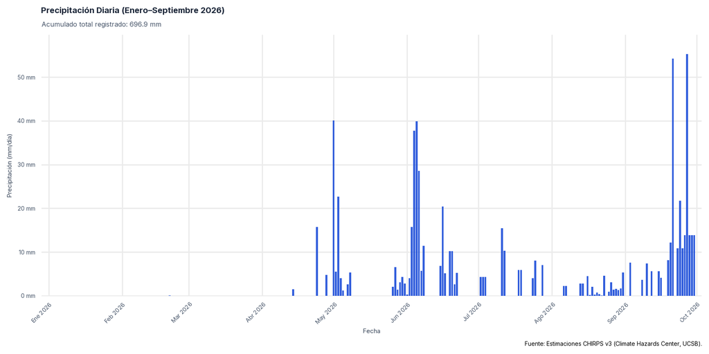

Figura 2.1: Distribución de precipitación diaria en Liberia (Enero–Septiembre 2026)

```r
ggplot(precipitacion_t2, aes(x = date, y = precipitation)) +
  geom_col(fill = "#1d4ed8", width = 0.8, alpha = 0.9) +
  scale_x_date(
    date_breaks = "1 month",
    labels = function(x) paste(meses_es[as.integer(format(x, "%m"))], format(x, "%Y")),
    expand = expansion(mult = c(0.01, 0.01))
  ) +
  scale_y_continuous(
    labels = label_number(suffix = " mm", decimal.mark = ","),
    expand = expansion(mult = c(0, 0.08))
  ) +
  labs(
    title = "Precipitación Diaria (Enero–Septiembre 2026)",
    subtitle = paste("Acumulado total registrado:", round(sum(precipitacion_t2$precipitation, na.rm = TRUE), 1), "mm"),
    x = "Fecha",
    y = "Precipitación (mm/día)",
    caption = "Fuente: Estimaciones CHIRPS v3 (Climate Hazards Center, UCSB)."
  )
```

Tal como se observa en la Figura 2.1, tras un repunte de lluvias en la primera mitad de junio (con eventos de casi 40 mm/día), desde finales de junio hasta finales de agosto se observa un veranillo (canícula) sumamente prolongado, donde las precipitaciones diarias rara vez superaron los 10 a 15 mm.

Al caer tanta agua en pocas horas tras semanas secas, el arrastre de sedimentos, polvo y residuos sólidos obstruye rápidamente el sistema de alcantarillado pluvial, provocando inundaciones en barrios vulnerables (como Pueblo Nuevo, Condega, El Capulín y Moracia) y crecidas súbitas del río Liberia a su paso por la ciudad.

**ImportanteSobre el evento del 2026-06-05**

Debido a múltiples incidentes causados por inundaciones asociadas a lluvias intensas, la Cruz Roja Costarricense reportó que los equipos de primera respuesta evacuaron a siete personas cuyas viviendas se inundaron por completo.

## 2.2 Temperatura Media Diaria

La evolución térmica observada en la Figura 2.2 muestra una variabilidad con medias diarias oscilando entre los 24 °C y 31 °C.

**Mostrar el código**

```r
datos_temp <- precipitacion_t2 |>
  mutate(
    etiqueta_tooltip = paste0(
      "<b>Fecha:</b> ", format(date, "%d/%m/%Y"),
      "<br><b>Temp. media:</b> ", round(tmean, 2), " °C",
      "<br><b>Rango:</b> ", round(tmin, 1), " – ", round(tmax, 1), " °C"
    )
  )

grafico_temp <- ggplot(datos_temp, aes(x = date, y = tmean)) +
  geom_line(aes(text = etiqueta_tooltip, group = 1), color = "#ea580c", linewidth = 0.7) +
  geom_smooth(method = "loess", span = 0.2, se = FALSE, color = "#b91c1c", linetype = "dashed", linewidth = 0.6) +
  scale_x_date(
    date_breaks = "1 month",
    labels = function(x) paste(meses_es[as.integer(format(x, "%m"))], format(x, "%Y")),
    expand = expansion(mult = c(0.01, 0.01))
  ) +
  scale_y_continuous(labels = label_number(suffix = " °C", decimal.mark = ",")) +
  labs(
    title = "Temperatura Media Diaria (ERA5-Land)",
    x = "Fecha",
    y = "Temperatura (°C)"
  )

ggplotly(grafico_temp, tooltip = "text") |>
  layout(
    hoverlabel = list(bgcolor = "white", font = list(size = 12)),
    margin = list(b = 85),
    annotations = list(
      list(
        text = "Línea continua: registro diario | Línea discontinua: tendencia LOESS | Fuente: ERA5-Land (ECMWF)",
        xref = "paper", yref = "paper",
        x = 0, y = -0.28,
        showarrow = FALSE,
        font = list(size = 10, color = "#64748b")
      )
    )
  ) |>
  config(locale = "es", displaylogo = FALSE)
```

[interactive chart not shown]

Figura 2.2: Comportamiento de la temperatura media diaria en Liberia

A partir de la Figura 2.2, se observa que la temperatura media en Liberia durante el período de enero a septiembre de 2026 presenta dos patrones . Desde inicios del año y hasta principios del mes de junio la temperatura mantiene una tendencia de crecimiento, alcanzando la mayor temperatura media diaria del año. En el segundo semestre al temperatura presenta una tendencia de disminución de temperaturas para el mes de junio y luego se recupera el crecimiento. No obstante la variación, las condiciones climáticas típicas de la región son generalmente cálidas durante todo el año.

Como respuesta a la pregunta sobre la temperatura y precipitación, se observa que en el segundo semestre la temperatura es menor y, en este período se tiene una mayor cantidad de lluvias. Ahora bien, Guanacaste tiene una marcada estación lluviosa (aproximadamente de mayo a noviembre) y una época seca (de diciembre/enero a abril) evidenciada en la Figura 2.1. Durante los meses secos, la menor nubosidad favorece temperaturas más altas y mayor evaporación, reduciendo la disponibilidad de agua en la cuenca.

Un fenómeno que se puede interpretar mejor observando la capa de topografía en la Figura 1.1 es que en las zonas más altas de la cuenca (como las laderas volcánicas), la temperatura media anual es menor (alrededor de 22 °C a 24 °C en la parte alta del río Tempisque) y las lluvias suelen ser más abundantes por efecto orográfico. En las partes medias y bajas (planicies), la temperatura sube (cerca de 26 °C a 28 °C) y el clima es más seco. Lo anterior también se puede comprobar por el análisis de las secciones siguientes, especialmente evidente en la Figura 3.1.

## 2.3 Curva Masa de Precipitación Acumulada

**Mostrar el código**

```r
# Cálculo de la precipitación acumulada
datos_curva_masa <- precipitacion_t2 |>
  arrange(date) |>
  mutate(
    precip_acumulada = cumsum(precipitation),
    etiqueta_tooltip = paste0(
      "<b>Fecha:</b> ", format(date, "%d/%m/%Y"), "<br>",
      "<b>Lluvia diaria:</b> ", number(precipitation, accuracy = 0.01, decimal.mark = ","), " mm<br>",
      "<b>Lluvia acumulada:</b> ", number(precip_acumulada, accuracy = 0.01, decimal.mark = ","), " mm"
    )
  )

grafico_curva <- ggplot(datos_curva_masa, aes(x = date, y = precip_acumulada)) +
  geom_area(fill = "#0284c7", alpha = 0.25) +
  geom_line(color = "#0369a1", linewidth = 0.8) +
  geom_point(aes(text = etiqueta_tooltip), color = "#0284c7", size = 1.1, alpha = 0.7) +
  scale_x_date(
    date_breaks = "1 month",
    labels = function(x) paste(meses_es[as.integer(format(x, "%m"))], format(x, "%Y")),
    expand = expansion(mult = c(0, 0.05))
  ) +
  scale_y_continuous(
    labels = label_number(suffix = " mm", decimal.mark = ","),
    expand = expansion(mult = c(0, 0.08))
  ) +
  labs(
    title = "Curva Masa de Precipitación Acumulada",
    x = "Fecha",
    y = "Precipitación Acumulada (mm)"
  )

ggplotly(grafico_curva, tooltip = "text") |>
  layout(
    hoverlabel = list(bgcolor = "white", font = list(size = 12)),
    margin = list(b = 85),
    annotations = list(
      list(
        text = "Área sombreada: volumen acumulado continuo | Fuente: CHIRPS v3 (UCSB)",
        xref = "paper", yref = "paper",
        x = 0, y = -0.28,
        showarrow = FALSE,
        font = list(size = 10, color = "#64748b")
      )
    )
  ) |>
  config(locale = "es", displaylogo = FALSE)
```

[interactive chart not shown]

Figura 2.3: Curva masa de precipitación acumulada en Liberia

# 3 Análisis Espacial de la Precipitación en la Subcuenca

En esta sección se describen los hallazgos clave del análisis espacial, destacando las zonas con mayor acumulación de precipitación y su relación con la topografía y el uso del suelo. Además, se discuten las implicaciones de estos resultados para la planificación urbana y la mitigación de riesgos asociados a eventos extremos de lluvia.

## 3.1 Carga y Resumen de Registros Diarios

En la Tabla 3.1 se presentan los registros pluviométricos con precisión geodésica de 5 decimales y lámina de lluvia a 2 decimales.

**Mostrar el código**

```r
# 1. Lectura remota única de la base de datos espacial diaria
url_csv_diaria <- "https://raw.githubusercontent.com/dennierchavez/Tarea_3/refs/heads/main/BD_CHIRPS_Diaria_Liberia.csv"
datos_chirps_df <- read_csv(url_csv_diaria, show_col_types = FALSE) |>
  rename_with(~ "fecha", any_of(c("fecha", "date", "Fecha"))) |>
  rename_with(~ "chirps", any_of(c("chirps", "precip", "precipitacion_mm"))) |>
  mutate(fecha = as.Date(fecha))

# 2. Despliegue interactivo en tabla DT
datos_chirps_df |>
  mutate(
    lon = round(lon, 5),
    lat = round(lat, 5),
    chirps = round(chirps, 2)
  ) |>
  rename(any_of(c(
    "ID Punto" = "id",
    "Longitud" = "lon",
    "Latitud" = "lat",
    "Fecha" = "fecha",
    "Precipitación (mm)" = "chirps"
  ))) |>
  datatable(
    rownames = FALSE,
    options = list(
      pageLength = 8,
      autoWidth = TRUE,
      language = list(
        search = "Buscar:",
        lengthMenu = "Mostrar _MENU_ filas",
        info = "Mostrando _START_ a _END_ de _TOTAL_ registros",
        paginate = list(previous = "Anterior", `next` = "Siguiente")
      )
    )
  )
```

Tabla 3.1: Muestra de registros diarios de precipitación CHIRPS en la subcuenca del Río Liberia

| ID Punto | Longitud | Latitud | Fecha | Precipitación (mm) |
| --- | --- | --- | --- | --- |
| 1 | -85.51811 | 10.46515 | 2026-01-01 | 0 |
| 1 | -85.51811 | 10.46515 | 2026-01-02 | 0 |
| 1 | -85.51811 | 10.46515 | 2026-01-03 | 0 |
| 1 | -85.51811 | 10.46515 | 2026-01-04 | 0 |
| 1 | -85.51811 | 10.46515 | 2026-01-05 | 0 |
| 1 | -85.51811 | 10.46515 | 2026-01-06 | 0 |
| 1 | -85.51811 | 10.46515 | 2026-01-07 | 0 |
| 1 | -85.51811 | 10.46515 | 2026-01-08 | 0 |
| 1 | -85.51811 | 10.46515 | 2026-01-09 | 0 |
| 1 | -85.51811 | 10.46515 | 2026-01-10 | 0 |

[output cut: 27490 more lines]

## 3.2 Procesamiento Espacial y Cambio de Proyección

Se calcula la precipitación total acumulada y la precipitación media anual por punto de control. Siguiendo las directrices del curso, se proyectan las capas del sistema **CRTM05 (EPSG:8908)** y se transforman a **WGS84 (EPSG:4326)** para su representación cartográfica.

**Mostrar el código**

```r
# 1. Agregación estadística por punto de muestreo
resumen_espacial_df <- datos_chirps_df |>
  mutate(anio = year(fecha)) |>
  group_by(id, lon, lat) |>
  summarise(
    dias_registrados      = n(),
    precip_acumulada_mm   = sum(chirps, na.rm = TRUE),
    precip_media_anual_mm = precip_acumulada_mm / n_distinct(anio),
    precip_max_diaria_mm  = max(chirps, na.rm = TRUE),
    .groups = "drop"
  )

# 2. Conversión a objeto sf en WGS84 (EPSG:4326)
puntos_sf <- resumen_espacial_df |>
  st_as_sf(coords = c("lon", "lat"), crs = 4326)

# 3. Transformación métrica a CRTM05 (EPSG:8908) y filtrado espacial
cuenca_crtm05  <- st_transform(subcuenca_sf, 8908)
puntos_crtm05  <- st_transform(puntos_sf, 8908)
puntos_filtrados_crtm05 <- st_filter(puntos_crtm05, cuenca_crtm05)

# 4. Proyección a WGS84 para cartografía
puntos_cuenca_wgs84 <- st_transform(puntos_filtrados_crtm05, 4326)

# Verificación de geometrías
st_crs(puntos_cuenca_wgs84)$srid
```

```
[1] "EPSG:4326"
```

## 3.3 Mapa Estático de Precipitación Acumulada (`ggplot2` + `geom_sf`)

La Figura 3.1 ilustra la variación espacial de la precipitación total acumulada en la subcuenca del río Liberia.

**Mostrar el código**

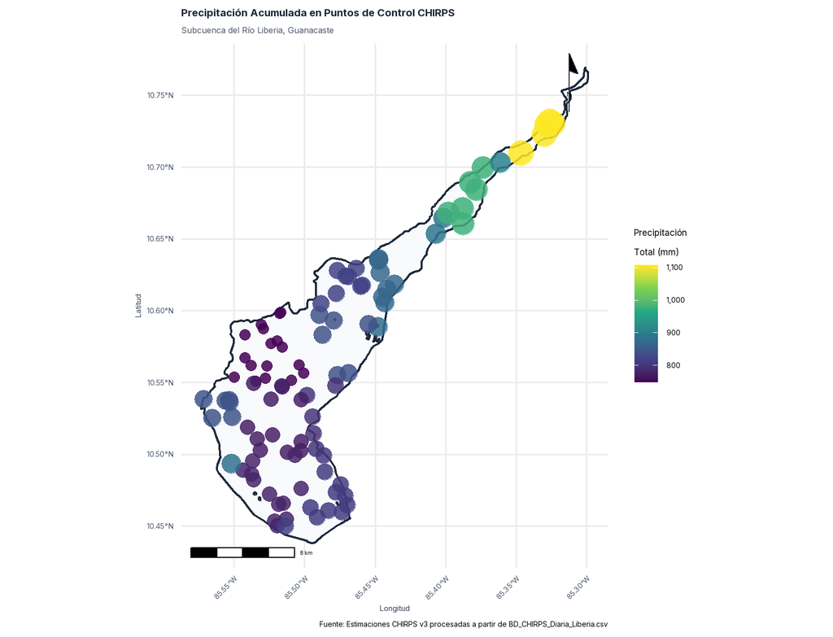

Figura 3.1: Distribución espacial de la precipitación acumulada en la subcuenca del Río Liberia

```r
ggplot() +
  # Polígono delimitador de la subcuenca
  geom_sf(data = subcuenca_sf, fill = "#f8fafc", color = "#1e293b", linewidth = 0.8) +
  # Puntos con escala graduada de lluvia acumulada
  geom_sf(
    data = puntos_cuenca_wgs84,
    aes(color = precip_acumulada_mm, size = precip_acumulada_mm),
    alpha = 0.85
  ) +
  scale_color_viridis_c(
    option = "viridis",
    name = "Precipitación\nTotal (mm)",
    labels = label_comma()
  ) +
  scale_size_continuous(range = c(3.5, 8.5), guide = "none") +
  annotation_scale(location = "bl", width_hint = 0.25) +
  annotation_north_arrow(
    location = "tr", which_north = "true",
    style = north_arrow_minimal(line_col = "#1e293b")
  ) +
  coord_sf() +
  labs(
    title = "Precipitación Acumulada en Puntos de Control CHIRPS",
    subtitle = "Subcuenca del Río Liberia, Guanacaste",
    x = "Longitud",
    y = "Latitud",
    caption = "Fuente: Estimaciones CHIRPS v3 procesadas a partir de BD_CHIRPS_Diaria_Liberia.csv"
  )
```

El mapa evidencia un marcado gradiente espacial noreste-suroeste: los sectores de cabecera en las inmediaciones del macizo volcánico Rincón de la Vieja concentran los mayores volúmenes de precipitación acumulada, superando ampliamente los registros de las planicies aluviales del sector bajo cercanas a la confluencia con el río Tempisque.

## 3.4 Mapa Interactivo de Precipitación (`leaflet`)

La Figura 3.2 permite explorar las lecturas puntuales mediante ventanas emergentes y etiquetas continuas.

**Mostrar el código**

```r
# Paleta continua basada en la precipitación acumulada
paleta_precip <- colorNumeric(
  palette = "YlGnBu",
  domain = puntos_cuenca_wgs84$precip_acumulada_mm
)

leaflet() |>
  # Mapas base seleccionables
  addProviderTiles(providers$OpenTopoMap, group = "OpenTopoMap") |>
  addProviderTiles(providers$OpenStreetMap, group = "OpenStreetMap") |>
  addProviderTiles(providers$Esri.WorldImagery, group = "Satélite (Esri)") |>

  # Delimitación de la subcuenca
  addPolygons(
    data = subcuenca_sf,
    color = "#03045e",
    weight = 2.5,
    opacity = 0.9,
    fillColor = "#0077b6",
    fillOpacity = 0.2,
    group = "Límite Subcuenca"
  ) |>

  # Puntos pluviométricos con popups informativos
  addCircleMarkers(
    data = puntos_cuenca_wgs84,
    radius = ~rescale(precip_acumulada_mm, to = c(6, 13)),
    color = "#0f172a",
    weight = 1.2,
    fillColor = ~paleta_precip(precip_acumulada_mm),
    fillOpacity = 0.9,
    group = "Precipitación Acumulada",
    popup = ~paste0(
      "<div style='font-family: Inter, sans-serif; font-size:12px;'>",
      "<h4 style='margin:0 0 5px 0; color:#0369a1;'>Punto ID: ", id, "</h4>",
      "<b>Lluvia Acumulada:</b> <span style='color:#b91c1c;'>", round(precip_acumulada_mm, 1), " mm</span><br>",
      "<b>Promedio Anual:</b> ", round(precip_media_anual_mm, 1), " mm/año<br>",
      "<b>Máximo Diario:</b> ", round(precip_max_diaria_mm, 1), " mm<br>",
      "<b>Coordenadas:</b> (", round(st_coordinates(puntos_cuenca_wgs84)[,2], 4), ", ", round(st_coordinates(puntos_cuenca_wgs84)[,1], 4), ")",
      "</div>"
    ),
    label = ~paste0("Punto ", id, ": ", round(precip_acumulada_mm, 1), " mm")
  ) |>

  # Leyenda continua
  addLegend(
    pal = paleta_precip,
    values = puntos_cuenca_wgs84$precip_acumulada_mm,
    title = "Precipitación (mm)",
    position = "bottomright",
    opacity = 0.9
  ) |>

  # Barra de escala métrica
  addScaleBar(
    position = "bottomleft",
    options = scaleBarOptions(imperial = FALSE)
  ) |>

  # Control de capas
  addLayersControl(
    baseGroups = c("OpenTopoMap", "OpenStreetMap", "Satélite (Esri)"),
    overlayGroups = c("Límite Subcuenca", "Precipitación Acumulada"),
    options = layersControlOptions(collapsed = FALSE)
  ) |>

  # Fuente visible en el mapa interactivo
  addControl(
    html = "<div style='background:rgba(255,255,255,0.85); padding:4px 8px; font-size:11px; border-radius:3px;'>Fuente: CHIRPS v3 (UCSB/CHC)</div>",
    position = "bottomleft"
  )
```

[interactive chart not shown]

Figura 3.2: Mapa interactivo de la precipitación en los puntos de control de la subcuenca del río Liberia

Los resultados muestran que las áreas más afectadas por la lluvia intensa se encuentran en las zonas montañosas del norte y este de la subcuenca, mientras que las zonas bajas y planas presentan menor variabilidad en la precipitación. Lo anterior es esperable según lo indicado en las secciones anteriores.

Una conclusión válida de lo mostrado en la Figura 3.2 es que las precipitaciones de mayor intensidad ocurren en la parte alta de la cuenca, mientras que en la zona urbana no se puede señalar el mismo comportamiento. Por lo tanto, las inundaciones ocasionadas por las lluvias en la zona urbana de Liberia probablemente tengan su origen en la alta escorrentía, una red de drenaje pluvial insuficiente para los caudales y en general por deficiencias en infraestructura y no por la cantidad de agua llovida.

# 4 Referencias Bibliográficas

- Funk, C., Peterson, P., Landsfeld, M., Pedreros, D., Verdin, J., Shukla, S., Husak, G., Rowland, J., Harrison, L., Hoell, A., y Michaelsen, J. (2015). The climate hazards infrared precipitation with stations—a new environmental record for monitoring extremes. *Scientific Data*, 2(1), 1-21.[doi.org](https://doi.org/10.1038/sdata.2015.66)
- Muñoz-Sabater, J., Dutra, E., Agustí-Panareda, A., Albergel, C., Arduini, G., Balsamo, G., Boussetta, S., Choulga, M., Harrigan, S., Hersbach, H., Martens, B., Miralles, D. G., Piles, M., Rodríguez-Fernández, N. J., Zsoter, E., Buontempo, C., y Thépaut, J.-N. (2021). ERA5-Land: A state-of-the-art global reanalysis dataset for land applications. *Earth System Science Data*, 13(9), 4349–4383.[doi.org](https://doi.org/10.24381/cds.68d2bb30)
- Pebesma, E., y Bivand, R. (2023). Spatial Data Science: With Applications in R (1st ed.). Chapman and Hall/CRC. [doi.org](https://doi.org/10.1201/9780429459016).

# 5 Declaración sobre el Uso de Herramientas de IA

En cumplimiento con los lineamientos del curso, se declara el uso del asistente Gemini Notebook (Google) para la depuración sintáctica del código Quarto, optimización de tuberías espaciales en `sf` y creación de un script para modificar el estilo del documento y uniformar visualmente las salidas cartográficas en `ggplot2` y `leaflet`, adicional se elaboró una lista de verificación para que fuera aplicada como una valoración preliminar de la tarea. Todos los análisis, selecciones de capas e interpretaciones hidrológicas fueron verificados por el autor.